# Listing Upgrades For Sale

With our shop interface in place, it’s time to connect it to the game. The idea is to read a given tower’s upgrades and list them using the panel we’ve created in the previous lesson. This panel should always be visible on screen.

We need to create a dynamic interface that adapts its position relative to the tower based, while staying within the screen’s bounds.

The *UIUpgradeShop* should also have access to the *Player* node to manage the transactions and update the *UIUpgradeButtons* to disable them if players can’t buy their upgrades.

Let’s dive into the actual script.

## Creating the upgrades shop

Attach a script to the *UIUpgradeShop* node and save it.

The first thing to do is export a variable that points to the *UIUpgradeButton*’s scene so we can create instances of these buttons based on the tower’s upgrades and list them in the panel.

We can create some references for children and the player. The *Game* will be responsible for injecting the player into the *UIUpgradeShop*. The header of our script should look like this:

```
class_name UpgradeShop
extends Control

export var _upgrade_button_scene: PackedScene

onready var _container := $Panel/VBoxContainer
onready var _anim_player := $AnimationPlayer
onready var _panel := $Panel

var player: Player
```

In the *Inspector*, drag the `UIUpgradeButton` scene to *Upgrade Button Scene* property.

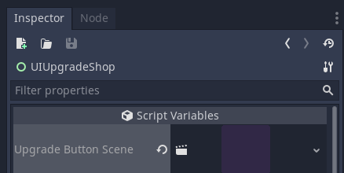

The panel should appear near to a selected tower. We make the *UIUpgradeShop* subscribe to the tower’s `selected` signal every time players place a new tower. We can use the *TowerPlacer* for that. The *Game* is going to subscribe the *UIUpgradeShop* to the *TowerPlacer*’s `tower_placed` signal. Before we satisfy these dependencies, let’s create the callback first.

We ask the tower to pass itself as an extra argument when it emits this signal. This is important so that we have access to its position and snap the shop interface to it.

```
func _on_TowerPlacer_tower_placed(tower: Tower) -> void:
    tower.connect("selected", self, "_on_Tower_selected", [tower])
    tower.connect("sold", self, "_on_Tower_sold")
```

In the `_on_Tower_sold()` callback, we tell the `_anim_player` to play the `"Disappear"` animation.

```
func _on_Tower_sold(_price: int, place: Vector2) -> void:
    _anim_player.play("Disappear")
```

As for the `_on_Tower_selected()` callback, we need to update the panel’s button and position based on the tower. We bundle this into the `_update()` method.

We use the `tower.get_upgrades()` method to access the tower’s upgrades. Then, we create an instance of a *UIUpgradeButton* for each upgrade. Our `_update()` method should look like this:

```
func _update(tower: Tower) -> void:
    rect_global_position = tower.global_position

  # We remove any buttons before populating the container with new ones.
    for child in _container.get_children():
        child.queue_free()

    for upgrade in tower.get_upgrades():
        add_upgrade_button(upgrade)
```

The `add_upgrade_button()` method receives an `upgrade` as argument. This is so we can pair buttons with their respective upgrades.

We create an instance of the `_upgrade_button_scene`. Then, we connect its `pressed` signal to a callback we’ll implement soon. Here we ask the `button` instance to pass itself **and** the `upgrade` as extra arguments every time it notifies the shop that it got pressed.

After that, we must update the `button` using the `upgrade` and the current `player.gold` amount.

After the `button` setup, we can add it as a child of the `_container`. This effectively displays it in the panel. Our `add_upgrade_button()` method ends up like this:

```
func add_upgrade_button(upgrade: Upgrade) -> void:
    var button: UIUpgradeButton = _upgrade_button_scene.instance()
    button.connect("pressed", self, "_on_UIUpgradeButton_pressed", [button, upgrade])
    button.update_display(upgrade, player.gold)

    _container.add_child(button)
```

In the `_on_UIUpgradeButton_pressed()` callback, we perform the upgrade transaction. Since it receives the `button` and the `upgrade`, we have everything we need to manage the purchase.

If the player has enough gold, we charge the player, apply the upgrade, and update the button. We need to update the button because, upgrades increase in price as we apply them.

```
func _on_UIUpgradeButton_pressed(button: UIUpgradeButton, upgrade: Upgrade) -> void:
    if player.gold < upgrade.cost:
        return
    player.gold -= upgrade.cost
    upgrade.apply()
    button.update_display(upgrade, player.gold)
```

Our shop has its main behavior in place, but it doesn’t appear when it needs to. In the `_on_Tower_selected()` callback, we show or hide the shop after updating it.

```
func _on_Tower_selected(selected: bool, tower: Tower) -> void:
    _update(tower)

    if selected:
        appear()
    else:
        disappear()
```

The `disappear()` callback tells the `_anim_player` to play the disappear animation.

We can also call this method instead in the `_on_Tower_sold()` callback:

```
func disappear() -> void:
    _anim_player.play("Disappear")

func _on_Tower_sold(_price: int, place: Vector2) -> void:
    disappear()
```

The `appear()` method gets a bit more complicated. We’ve decided the panel should appear in the top portion of the tower. Like so:

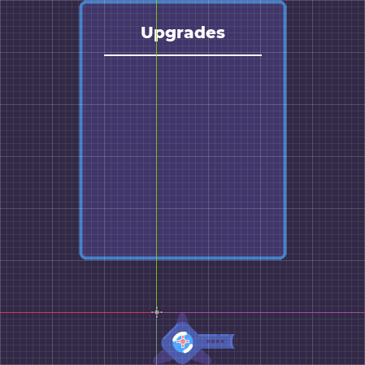

But for that to happen, we need to rotate the *UIUpgradeShop* `rect` by `-90` degrees. Which leads to this:

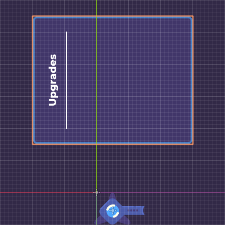

As you can see the panel also rotates. This is not ideal, it should always look the same, regardless of its parent’s rotation. To compensate, we need to rotate the panel’s `rect` by the inverse rotation of the *UIUpgradeShop*.

What should happen if the panel gets cut off the screen due to the tower being close to, or at, the screen edges? Like so:

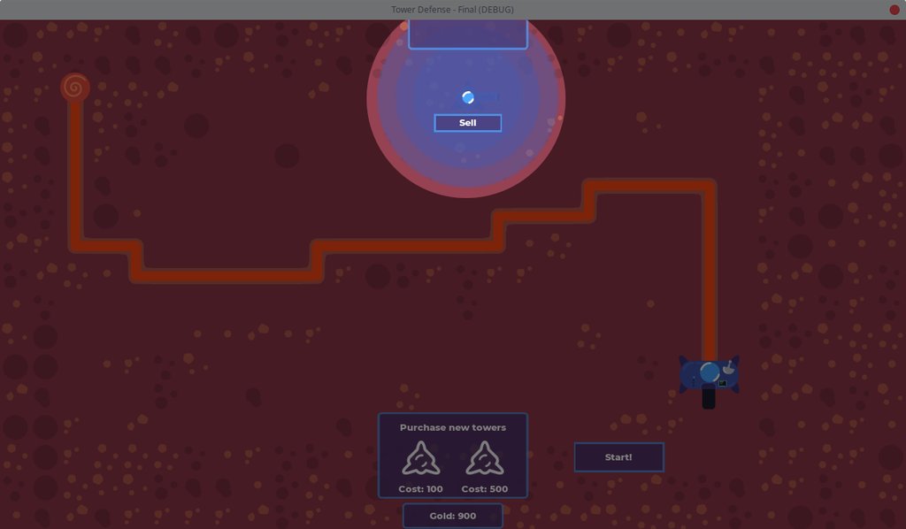

We need to know if this cutoff happened by using the viewport’s rect and test if it encloses the panel’s rect. If that’s the case, we fit the panel to the screen. We call a new method called `_fit_panel_in_view()` before finally telling the `_anim_player` to player the `"Appear"` animation.

```
func appear() -> void:
    # Reset rotation to appear at tower's top portion
    rect_rotation = -90
    _panel.rect_rotation = 90

    # Rotate to always display the panel on screen. Fix cases where
    # players place towers near/at screen's edges
    if not get_viewport_rect().encloses(_panel.get_global_rect()):
        _fit_panel_in_view()
    _anim_player.play("Appear")
```

To fit the panel inside the screen, we rotate the *UIUpgradeShop* to always look to screen’s center. Let’s see how this works.

In the `_fit_panel_in_view()` method we access the viewport’s rect size and multiply it by `0.5` so we find its center. Then, using

[figure not shown]

`Vector2`’s `angle_to_point()` method, we find the angle we need from the center to the *UIUpgradeShop*’s rect’s center using its position subtracted by its offset.

```
# Uses rotation to ensure the interface is always in the view.
func _fit_panel_in_view() -> void:
    var center := get_viewport_rect().size * 0.5
    var angle := center.angle_to_point(rect_global_position - rect_pivot_offset)
```

Just that can cause some weird situations such as micro rotations due to small differences between the tower’s position and the viewport’s center. Instead of rotating the shop by exactly the angle we found, we snap it to `45` degree increments. As the `angle_to_point()` returns angles in radians, we can use `PI / 4` instead.

```
func _fit_panel_in_view() -> void:
    # ...
    # Snap angle to 45 degrees increment
    angle = round(angle / (PI / 4)) * (PI / 4)
```

We convert this angle to degrees and set it as the *UIUpgradeShop*’s `rect_rotation`. Remember that we need to compensate this rotation in the panel to keep its design. This is how the `_fit_panel_in_view()` method should look:

```
# Uses rotation to ensure the interface is always in the view.
func _fit_panel_in_view() -> void:
    var center := get_viewport_rect().size * 0.5
    var angle := center.angle_to_point(rect_global_position - rect_pivot_offset)
    # Snap angle to 45 degrees increment
    angle = round(angle / (PI / 4)) * (PI / 4)

    rect_rotation = rad2deg(angle)
    # Compensates panel for parent's rotation
    _panel.rect_rotation = - rect_rotation
```

And it’s done! Our shop is ready to use. We just need to plug it with the level in using the *Game*. Let’s take a look on how this script ended up.

## Code so far

After implementing all its behaviors, the *UIUpgradeShop*’s script should look like this:

`UIUpgradeShop.gd`

```
class_name UpgradeShop
extends Control

export var _upgrade_button_scene: PackedScene

onready var _container := $Panel/VBoxContainer
onready var _anim_player := $AnimationPlayer
onready var _panel := $Panel

var player: Player


func appear() -> void:
    rect_rotation = -90
    _panel.rect_rotation = 90
    if not get_viewport_rect().encloses(_panel.get_global_rect()):
        _fit_panel_in_view()
    _anim_player.play("Appear")


func disappear() -> void:
    _anim_player.play("Disappear")


func add_upgrade_button(upgrade: Upgrade) -> void:
    var button: UIUpgradeButton = _upgrade_button_scene.instance()
    button.connect("pressed", self, "_on_UIUpgradeButton_pressed", [button, upgrade])
    button.update_display(upgrade, player.gold)

    _container.add_child(button)


func _update(tower: Tower) -> void:
    rect_global_position = tower.global_position

    for child in _container.get_children():
        child.queue_free()

    for upgrade in tower.get_upgrades():
        add_upgrade_button(upgrade)


# Uses rotation to ensure the interface is always in the view.
func _fit_panel_in_view() -> void:
    var center := get_viewport_rect().size * 0.5
    var angle := center.angle_to_point(rect_global_position - rect_pivot_offset)
    angle = round(angle / (PI / 4)) * (PI / 4)

    rect_rotation = rad2deg(angle)
    _panel.rect_rotation = - rect_rotation


func _on_TowerPlacer_tower_placed(tower: Tower) -> void:
    tower.connect("selected", self, "_on_Tower_selected", [tower])
    tower.connect("sold", self, "_on_Tower_sold")


func _on_Tower_selected(selected: bool, tower: Tower) -> void:
    _update(tower)

    if selected:
        appear()
    else:
        disappear()


func _on_Tower_sold(_price: int, place: Vector2) -> void:
    disappear()


func _on_UIUpgradeButton_pressed(button: UIUpgradeButton, upgrade: Upgrade) -> void:
    if player.gold < upgrade.cost:
        return
    player.gold -= upgrade.cost
    upgrade.apply()
    button.update_display(upgrade, player.gold)
```

## Adding the upgrade shop to the game

Open the `res://Game.tscn` scene and instance the *UIUpgradeShop* as a child of the *HUD* node. Then open the `res://Game.gd` script.

Create an `onready` variable as a reference to the upgrades shop.

Before we setup the level, we need to inject the `_player` into the `_upgrade_shop.player`. In the `_setup_level()` method, we connect the `_level.tower_placer`’s `tower_placed` signal to the `_upgrade_shop`’s `_on_TowerPlacer_tower_placed()` callback.

This is how the `Game.gd`’s `_ready()` and `_setup_level()` should look like after these changes.

`Game.gd`

```
onready var _upgrade_shop := $UILayer/UI/HUD/UIUpgradeShop


func _ready() -> void:
    _tower_shop.player = _player
    _gold_panel.player = _player
    _upgrade_shop.player = _player
    _setup_level()
    _level.start()


func _setup_level() -> void:
    _level.connect("base_destroyed", self, "_on_Level_base_destroyed")
    _level.connect("finished", self, "_on_Level_finished")
    _level.connect("gold_earned", self, "_on_Level_gold_earned")
    _level.connect("round_finished", self, "_on_Level_round_finished")

    _level.tower_placer.connect("tower_placed", _tower_shop, "_on_TowerPlacer_tower_placed")
    _level.tower_placer.connect("tower_placed", _upgrade_shop, "_on_TowerPlacer_tower_placed")
    _tower_shop.connect("tower_purchased", _level.tower_placer, "add_new_tower")
```

With that we should be able to test our upgrade system in action! Run the game, place a tower and it should immediately display a list of upgrades.

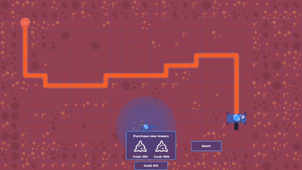